# Introduction to R: Custom Functions

⇦ Back

# 1 Built-In vs Package vs Custom Functions

## 1.1 Built-In Functions

When you download and open R for the first time you have access to all of the functions in the *base* library. These include all the ones you use most often. A complete list can be found on [this](https://stat.ethz.ch/R-manual/R-devel/library/base/html/00Index.html) page.

Here are some of the functions included in base R:

```r
# Replace all instances of a substring in a string
gsub("2", "to", "2 be or not 2 be")
# Replace the first instance of a substring in a string
sub("quest", "question", "that is the quest")
# Create a file path by adding in "/" on macOS and Linux and "\" on Windows
# between the words
file.path("Desktop", "New Folder", "Memes")
# List the files in a folder
list.files(".")
# Create a vector
c(12, 18, 15, 13)
# Take the mean (average) of the given numbers
mean(c(12, 18, 15, 13))
```

You can do a lot with the functions in base R, but often you need to do something that’s more complicated. For these occasions, you’ll need to use functions from a *library* or package.

## 1.2 Packages’ Functions

Let’s say you want to do some statistics using a Normal distribution and plot a graph. Base R doesn’t include anything to generate Normal data and, while it does have the `plot()` function, it can be quite limited. We can do a lot more if we import the `stats` and `ggplot` packages:

```r
library(stats)
library(ggplot2)
```

These give us access to hundreds of new functions, including `dnorm()` (which produces the density of a Normal distribution at given points) and `ggplot()` (which produces nice graphs):

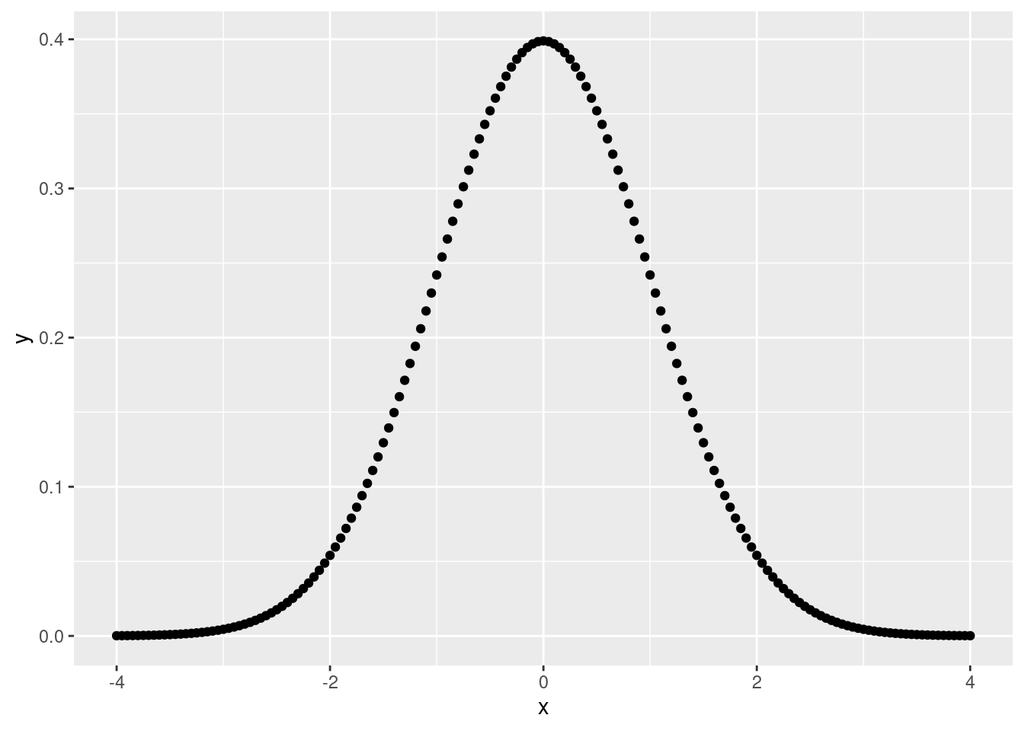

```r
x <- seq(-4, 4, by = 0.05)
df <- data.frame(
    x = x,
    y = stats::dnorm(x, mean = 0, sd = 1)
)
ggplot2::ggplot(df) + ggplot2::geom_point(aes(x, y))
```

Notice that in the code that generated this graph I explicitly showed which package each function came from using the double colon notation `::`. I used `stats::dnorm()` to show that `dnorm()` comes from the `stats` library and likewise with `ggplot2::ggplot()` and `ggplot2::geom_point()` from `ggplot2`. It’s actually not necessary to do this - R can guess which library each function comes from - but sometimes it’s useful to remind the person reading your code what libraries you are using (especially when using more obscure packages).

## 1.3 Custom Functions

Take a look at the following code which records the amount of time it took four people to run 5 km and converts these into speed in km/hr:

```r
library(chron)

distance <- 5  # km
runner_1 <- "00:18:47"
runner_2 <- "00:19:03"
runner_3 <- "00:19:20"
runner_4 <- "00:19:54"

speed_runner_1 <- as.numeric(distance / times(runner_1) / 24)
speed_runner_2 <- as.numeric(distance / times(runner_2) / 24)
speed_runner_3 <- as.numeric(distance / times(runner_3) / 24)
speed_runner_4 <- as.numeric(distance / times(runner_4) / 24)

sprintf(
    "Runner 1 ran %s km in %s at a speed of %5.2f km/hr",
    distance, runner_1, speed_runner_1
)
sprintf(
    "Runner 2 ran %s km in %s at a speed of %5.2f km/hr",
    distance, runner_2, speed_runner_2
)
sprintf(
    "Runner 3 ran %s km in %s at a speed of %5.2f km/hr",
    distance, runner_3, speed_runner_3
)
sprintf(
    "Runner 4 ran %s km in %s at a speed of %5.2f km/hr",
    distance, runner_4, speed_runner_4
)
```

```
## [1] "Runner 1 ran 5 km in 00:18:47 at a speed of 15.97 km/hr"
## [1] "Runner 2 ran 5 km in 00:19:03 at a speed of 15.75 km/hr"
## [1] "Runner 3 ran 5 km in 00:19:20 at a speed of 15.52 km/hr"
## [1] "Runner 4 ran 5 km in 00:19:54 at a speed of 15.08 km/hr"
```

Although the code works fine there is an awful lot of repetition! There is a principle in programming called DRY: don’t repeat yourself. In general, if you find yourself copy-pasting code from within your own script or performing the same calculation more that twice you should consider moving it to it’s own function:

```r
time_to_speed <- function(i, time, distance) {
    speed <- as.numeric(distance / times(time) / 24)
    msg <- sprintf(
        "Runner %s ran %s km in %s at a speed of %5.2f km/hr",
        i, distance, time, speed
    )
    print(msg)
}

distance <- 5  # km
times <- c("00:18:47", "00:19:03", "00:19:20", "00:19:54")
for (i in seq_along(times)) {
    time_to_speed(i, times[i], distance)
}
```

```
## [1] "Runner 1 ran 5 km in 00:18:47 at a speed of 15.97 km/hr"
## [1] "Runner 2 ran 5 km in 00:19:03 at a speed of 15.75 km/hr"
## [1] "Runner 3 ran 5 km in 00:19:20 at a speed of 15.52 km/hr"
## [1] "Runner 4 ran 5 km in 00:19:54 at a speed of 15.08 km/hr"
```

You have the same output with no repetition. This is the power of a function. Note how it has been created:

- The function is assigned to the name `time_to_speed` which hints at the fact that you are converting time into speed
- The word `function` is used
- Round brackets are used to list the *arguments* or inputs to the function, in this case:
  - `i`: which number runner it is
  - `time`: that runner’s time as a string in hr:min:sec format
  - `distance`: the length of the race in km
- The steps performed by the function are detailed between curly brackets

You could clean the code up even further by moving the function into a separate file and importing it as if it were a library.

# 2 ‘Apply’ Functions to Data

If you give a column of a data frame to a function, how will the function know whether you want it to act on the column as a whole (ie treat the column as one thing) or on every individual item in the column in turn (ie treat the column as multiple things)? What if you have a multi-step function with many if-else statements determining what happens? One way to deal with complicated situations like this is to define a custom function and then *apply* it to an input. Here’s an example that uses a subset of the built-in **iris** dataset:

```r
# Create the data to be used in this example
df = iris[c(1, 2, 3, 51, 52, 53, 101, 102, 103), ]
print(df)
```

```
##     Sepal.Length Sepal.Width Petal.Length Petal.Width    Species
## 1            5.1         3.5          1.4         0.2     setosa
## 2            4.9         3.0          1.4         0.2     setosa
## 3            4.7         3.2          1.3         0.2     setosa
## 51           7.0         3.2          4.7         1.4 versicolor
## 52           6.4         3.2          4.5         1.5 versicolor
## 53           6.9         3.1          4.9         1.5 versicolor
## 101          6.3         3.3          6.0         2.5  virginica
## 102          5.8         2.7          5.1         1.9  virginica
## 103          7.1         3.0          5.9         2.1  virginica
```

Now, here’s a function that finds flowers of the ‘virginica’ species:

```r
find_virginica <- function(val) {
    if (val == "virginica") {
        return(TRUE)
    } else {
        return(FALSE)
    }
}
```

```r
virginica_flowers = sapply(df[["Species"]], find_virginica)
print(virginica_flowers)
```

```
## [1] FALSE FALSE FALSE FALSE FALSE FALSE  TRUE  TRUE  TRUE
```

It has correctly identified that only the last three rows refer to virginica flowers. Now, here’s sapply being used on multiple columns at once:

```r
for (colname in colnames(df)) {
    df[[colname]] <- sapply(df[[colname]], find_virginica)
}
print(df)
```

```
##     Sepal.Length Sepal.Width Petal.Length Petal.Width Species
## 1          FALSE       FALSE        FALSE       FALSE   FALSE
## 2          FALSE       FALSE        FALSE       FALSE   FALSE
## 3          FALSE       FALSE        FALSE       FALSE   FALSE
## 51         FALSE       FALSE        FALSE       FALSE   FALSE
## 52         FALSE       FALSE        FALSE       FALSE   FALSE
## 53         FALSE       FALSE        FALSE       FALSE   FALSE
## 101        FALSE       FALSE        FALSE       FALSE    TRUE
## 102        FALSE       FALSE        FALSE       FALSE    TRUE
## 103        FALSE       FALSE        FALSE       FALSE    TRUE
```

The `find_virginica()` function has found all the instances of virginica flowers in the table by looking at each row in each column in turn.

# 3 Summary

- Functions are units of code that perform a specific task, such as a statistical test, the plotting of a graph or the conversion of time into speed
- Many functions are included in **base R**, many more are available through importing **libraries** and even more are possible when **created by the user**.
- Advantages of using functions are that you **avoid the repetition of your own code** and you can **use someone else’s code** without having to re-invent it.
- The cleanest code will have functions in **separate files** and then import them into the main script.
- Complex functions can be **applied** to data.

⇦ Back